# Titanic Data Analysis

#### 7.2.1.3 Regression Performance

All classification metrics are calculated from the out-of-fold (*OOF*) predictions collected across the CV procedure, Using a single set of OOF predictions keeps the reported performance metrics consistent with the ROC curves and the final confusion matrix.

| Feature Set | AUC | Accuracy | Sensitivity | Specificity | F1 |
| --- | --- | --- | --- | --- | --- |
| Full Features | 0.8436 | 0.7925 | 0.6935 | 0.8542 | 0.7197 |
| 2D MDS | 0.8225 | 0.7674 | 0.6709 | 0.8276 | 0.6890 |
| 2D PCA | 0.6589 | 0.6680 | 0.3166 | 0.8871 | 0.4228 |
| Full + 2D MDS | 0.8483 | 0.8002 | 0.7161 | 0.8527 | 0.7336 |

Table 10: Logistic Regression Performance Metrics Across Feature Spaces (10-fold CV)

The results in Table 10 shows differences between the feature spaces. The hybrid space, combining the baseline features with the 2D MDS coordinates, gives the strongest overall results, with $\text{AUC} = 0.8483$, $\text{Accuracy} = 0.8002$, $\text{F1} = 0.7336$. This suggests that the MDS coordinates capture additional information that is not fully represented by the original variables, resulting in a small improvement in classification performance.

The 2D MDS representation also performs relatively well on its own. Its AUC of $0.8225$ is close to the baseline value of $0.8436$, retaining approximately $97.5\%$ of the baseline AUC. Despite reducing the data to only two dimensions, MDS therefore preserves most of the information relevant for separating the two classes.

In contrast, the 2D PCA representation performs substantially worse. Its AUC drops to $0.6589$, while sensitivity falls to $0.3166$. This indicates that the linear PCA projection loses important information needed for classification.

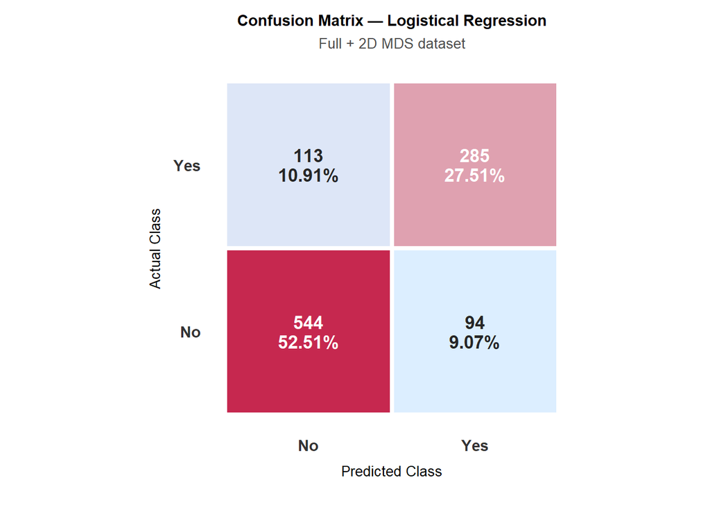

Figure 25: Confusion Matrix Heatmap for Best Model (Full + 2D MDS).

The confusion matrix (Figure 25) for the `Full + 2D MDS` model shows that the model performs better at identifying non-survivors than survivors. It correctly classifies $544$ non-survivors, corresponding to $52.51\%$ of all observations. This results in a specificity of $85.27\%$, with $94$ false positives ($9.07\%$ of all observations).

For survivors, the model correctly identifies $285$ cases, corresponding to $27.51\%$ of all observations, giving a sensitivity of $71.61\%$. There are $113$ false negatives ($10.91\%$ of all observations), where survivors are classified as non-survivors. Overall, the confusion matrix indicates that the number of false positives and false negatives is relatively similar.

### 7.2.2 $k$-Nearest Neighbours

The $k$-Nearest Neighbors ($k$-NN) algorithm is a non-parametric method that predicts the outcome based on the values of an observation’s $k$ closest neighbours in the feature space. Since $k$-NN relies on distance-based measures, the features were standardized independently within each CV fold.

#### 7.2.2.1 Parameter Tuning

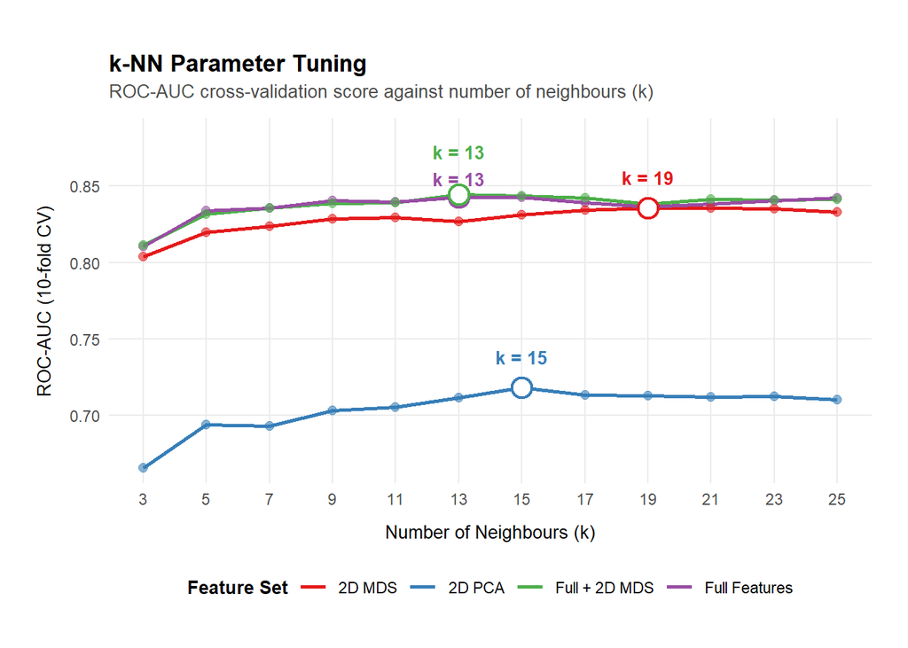

Figure 26: Optimization of hyperparameter $k$ across tested feature spaces.

To find the optimal parameter for each feature space, different values of $k$ were evaluated using 10-fold CV (Figure 26). The selected $k$ values vary slightly across representations: $k = 13$ for both `Full Features` and `Full + 2D MDS`, $k = 19$ for `2D MDS`, and $k = 15$ for `2D PCA`.

For the top three feature sets, the tuning curves remain remarkably stable near $\text{AUC} \approx 0.84$, indicating low sensitivity to the exact choice of $k$. In contrast, `2D PCA` underperforms across the entire search range, peaking at an $\text{AUC}$ of just $0.72$.

#### 7.2.2.2 Comparing Different Feature Spaces

To evaluate classification performance across different feature sets for the tuned $k$-NN models, ROC curves were generated using out-of-fold CV predictions (Figure 27).

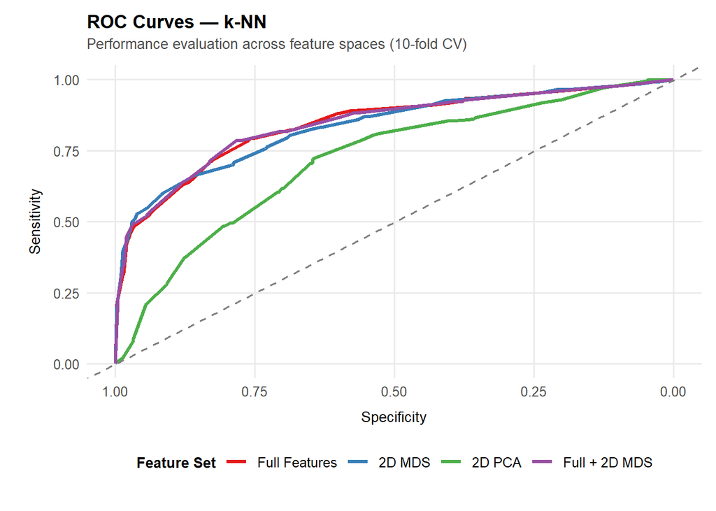

Figure 27: ROC Curves Comparison Across Feature Spaces for $k$-NN.

The ROC curves show that `Full Features`, `2D MDS`, and `Full + 2D MDS` achieve virtually identical and consistently high performance. Since $k$-NN is based on distances between observations, the 2D Gower MDS representation appears to preserve the most relevant distance relations from the original feature space. In contrast, the 2D PCA representation performs noticeably worse.

#### 7.2.2.3 $k$-NN Performance

All classification metrics were calculated from pooled out-of-fold predictions obtained through 10-fold CV (Table 11).

| Feature Set | AUC | Accuracy | Sensitivity | Specificity | F1 |
| --- | --- | --- | --- | --- | --- |
| Full Features | 0.8418 | 0.7838 | 0.6357 | 0.8762 | 0.6932 |
| 2D MDS | 0.8343 | 0.7944 | 0.5980 | 0.9169 | 0.6909 |
| 2D PCA | 0.7175 | 0.6805 | 0.4874 | 0.8009 | 0.5396 |
| Full + 2D MDS | 0.8430 | 0.7857 | 0.6432 | 0.8746 | 0.6975 |

Table 11: $k$-NN Performance Metrics Across Feature Spaces (10-fold CV).

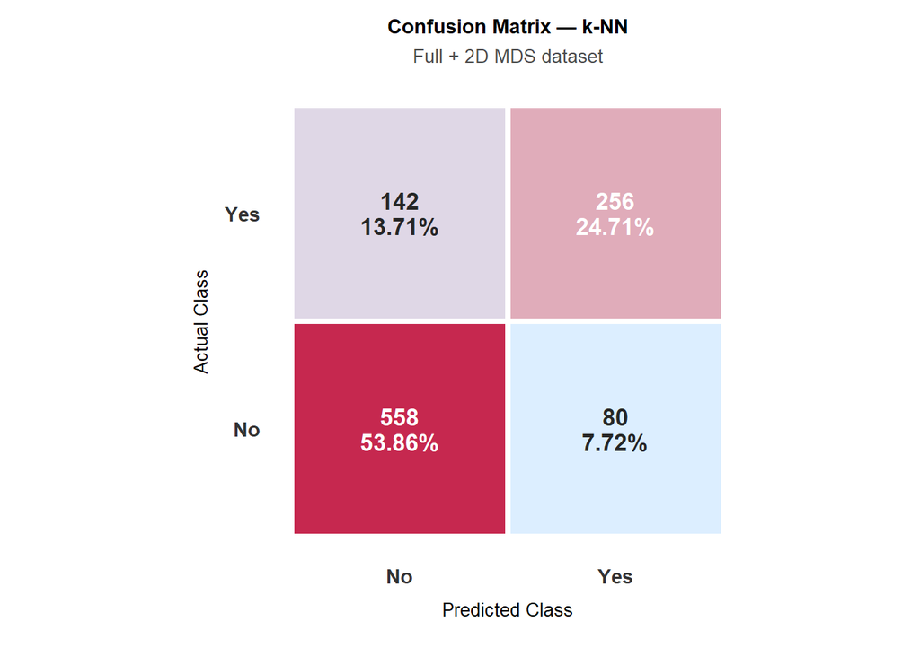

Figure 28: Confusion Matrix Heatmap for Best Model (Full + 2D MDS).

### 7.2.3 Decision Tree

The *Decision Tree* (DT) algorithm is a non-parametric method that makes predictions by recursively splitting the data based on the values of individual features. Since the model does not rely on distances between observations, the features were not standardized within the cross-validation folds.

#### 7.2.3.1 Parameter Tuning

The complexity parameter ($cp$) controls the size of the tree by determining whether a split should be made. Higher values of $cp$ result in simpler trees, while lower values allow the tree to grow more complex.

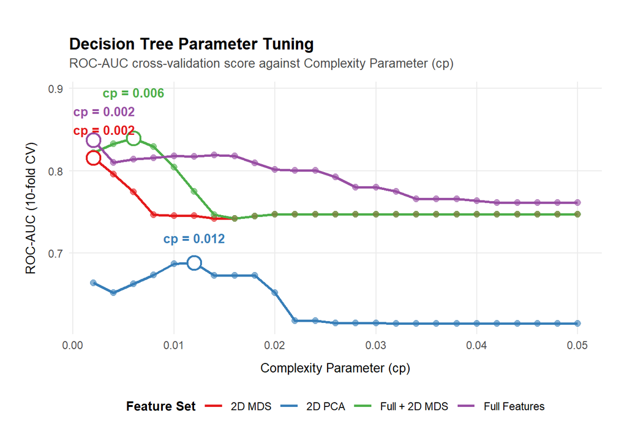

Figure 29: Optimization of hyperparameter $cp$ across tested feature spaces.

To find the optimal Complexity Parameter ($cp$) for each feature space, values ranging from $0.002$ to $0.05$ were evaluated using 10-fold CV (Figure 29). The optimal settings favor relatively unpruned trees: $cp = 0.002$ for `Full Features` and `2D MDS`, $cp = 0.006$ for `Full + 2D MDS`, and $cp = 0.012$ for `2D PCA`.

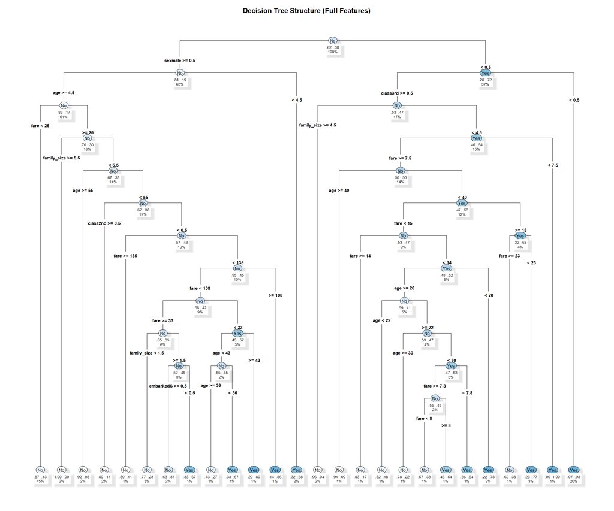

Figure 30: Final pruned Decision Tree structure trained on Full Features.

The structure of the decision tree trained on `Full Features` ($cp = 0.002$) is presented in Figure 30.

As expected, sex serves as the primary root split, while passenger class, age, and family size determine subsequent branches. While the upper levels provide clear, general rules, the lower nodes capture more detailed interactions between features because the tree is less heavily pruned.

#### 7.2.3.2 Comparing Different Feature Spaces

To evaluate classification performance across feature spaces for the tuned Decision Tree models, ROC curves were generated using out-of-fold CV predictions (Figure 31).

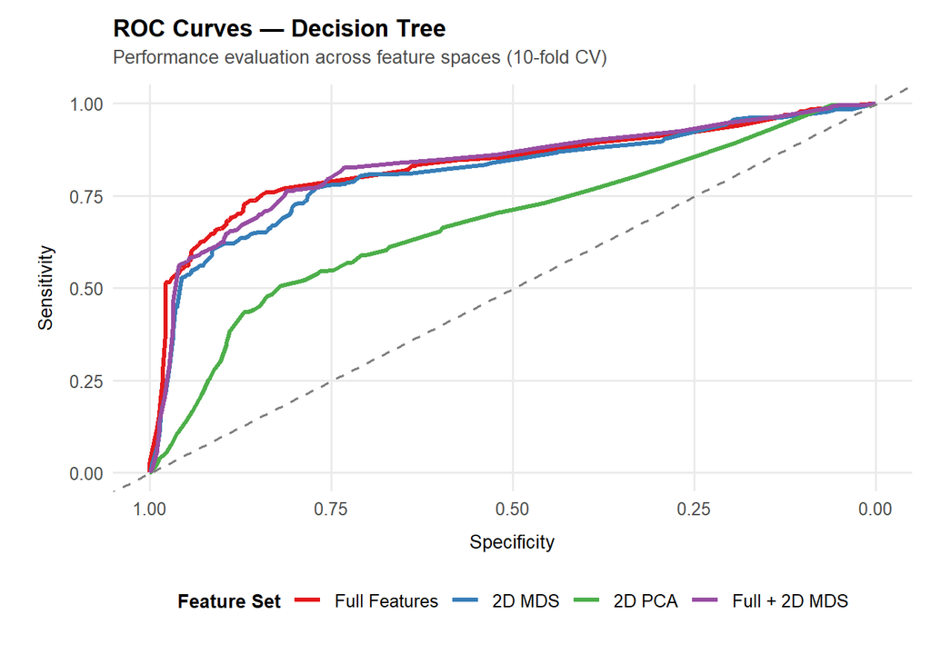

Figure 31: ROC Curves Comparison Across Feature Spaces for the Decision Tree.

The ROC curves show that `Full Features` and `Full + 2D MDS` achieve the highest overall performance, closely followed by `2D MDS`. Decision trees work well with the raw categorical features and the non-linear Gower MDS coordinates because they can effectively separate observations using simple threshold-based splits. In contrast, `2D PCA` performs significantly worse.

#### 7.2.3.3 Decision Tree Performance

All classification metrics were calculated from pooled out-of-fold predictions obtained through 10-fold CV (Table 12).

| Feature Set | AUC | Accuracy | Sensitivity | Specificity | F1 |
| --- | --- | --- | --- | --- | --- |
| Full Features | 0.8336 | 0.8118 | 0.6809 | 0.8934 | 0.7354 |
| 2D MDS | 0.8110 | 0.7770 | 0.6457 | 0.8589 | 0.6899 |
| 2D PCA | 0.6756 | 0.6969 | 0.4422 | 0.8558 | 0.5285 |
| Full + 2D MDS | 0.8316 | 0.7963 | 0.6558 | 0.8840 | 0.7121 |

Table 12: Decision Tree Performance Metrics Across Feature Spaces (10-fold CV).

The `Full Feature` space achieved the best results, with the highest $\text{AUC}$ ($0.8336$), $\text{Sensitivity}$ ($0.6809$), and $\text{F1}$ score ($0.7354$), closely followed by the hybrid space (`Full + 2D MDS`). `2D PCA` performed noticeably worse across all metrics, with an $\text{AUC}$ of only $0.6756$.

To further examine the classification errors of the `Full Features` model, its out-of-fold confusion matrix is shown below (Figure 32).

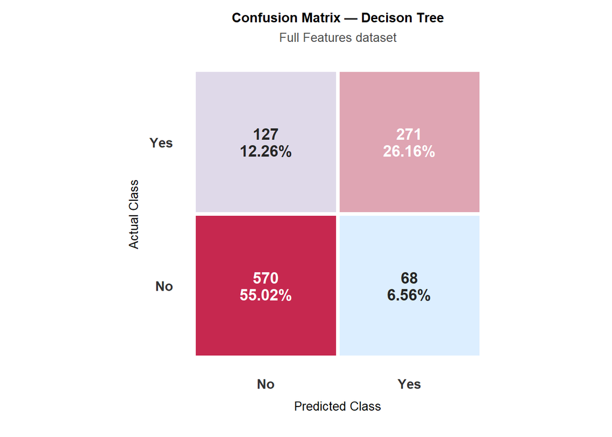

Figure 32: Confusion Matrix Heatmap for Best Model (Full Features).

The confusion matrix for the `Full Features` model shows a higher specificity than sensitivity. The model correctly classifies $570$ non-survivors, corresponding to $55.02%$ of all observations, resulting in a specificity of $89.34\%$. It produces $68$ false positives, which account for $6.56\%$ of all observations.

Among survivors, the model correctly identifies $271$ cases, corresponding to a sensitivity of $68.09%$. The remaining $127$ survivors are incorrectly classified as non-survivors, representing $12.26\%$ of all observations. Overall, false negatives are more frequent than false positives, indicating that the model misses more survivors than it incorrectly identifies non-survivors.

### 7.2.4 Random Forest

Random Forest algorithm is a non-parametric method that combines multiple decision trees to make predictions. Each tree is trained using a randomly selected subset of observations and features, and the final prediction is obtained by combining the predictions of individual trees. Since the model does not rely on distances between observations, the features were not standardized within CV folds.

#### 7.2.4.1 Model Configuration and Tuning

To improve the stability and performance of the models, several settings were changed:

- Ensemble size — 1000 classification trees were used to obtain more stable out-of-fold probability predictions.
- Parameter Tuning — models were tested with different values of `mtry` (the number of features considered at each split), while `min.node.size` was set to 20. Model performance was evaluated using 10-fold CV.

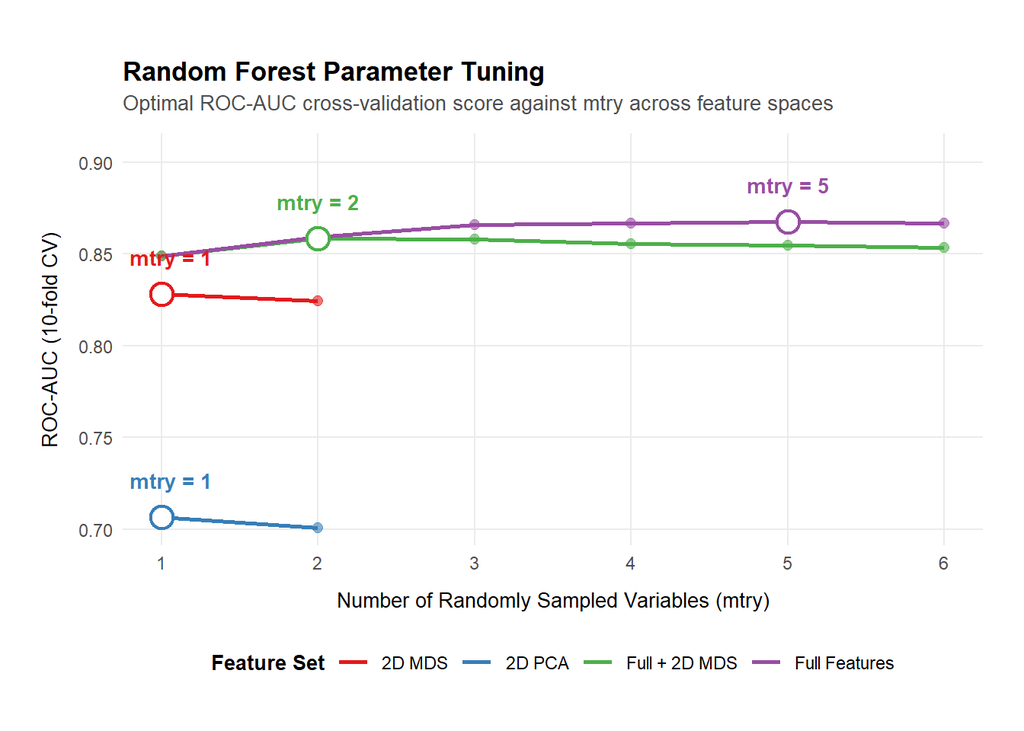

(a) Optimization of parameter $mtry$ across tested feature spaces.

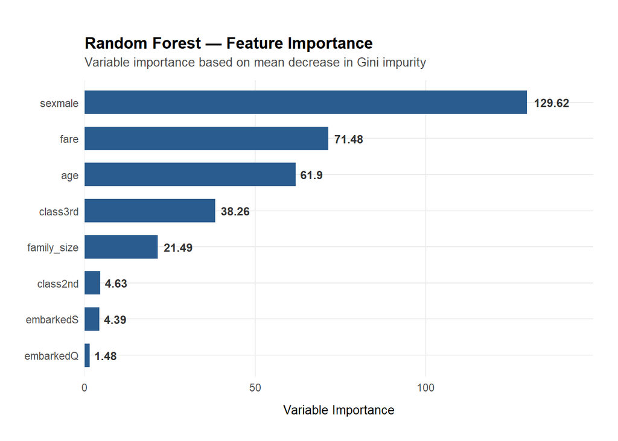

(b) Feature Importance of `Full Features` model.

Figure 33: Random Forest Model Configuration and Tuning

The tuning results (Figure 33 (a)) show that the optimal parameters vary depending on the dataset. For the `Full Features` model, the highest performance was achieved with $mtry = 5$ ($\text{AUC} \approx 0.87$). This suggests that considering several predictors at each split helped the model capture crucial relationships between variables. In the simpler `2D PCA` and `2D MDS` representations, the best results were obtained with $mtry = 1$, which shouldn’t be surprising as there are only two variables in those sets (two dimensions of MDS/PCA).

The feature importance results for `Full Features` (Figure 33 (b)) are also consistent with the patters observed in the previous models (see Figure 30 and Table 9). `sexmale` is by far the most important variable, with Gini importance of approximately $130$. Other variables, including `fare`, `age`, `class3rd`, and `family_size`, also have a noticeable influence on the model’s predictions. In contrast, the embarkation variables have relatively little impact.

#### 7.2.4.2 Comparing Different Feature Spaces

To evaluate classification performance across different feature sets for the tuned Random Forest models, ROC curves were generated using out-of-fold CV predictions (Figure 34).

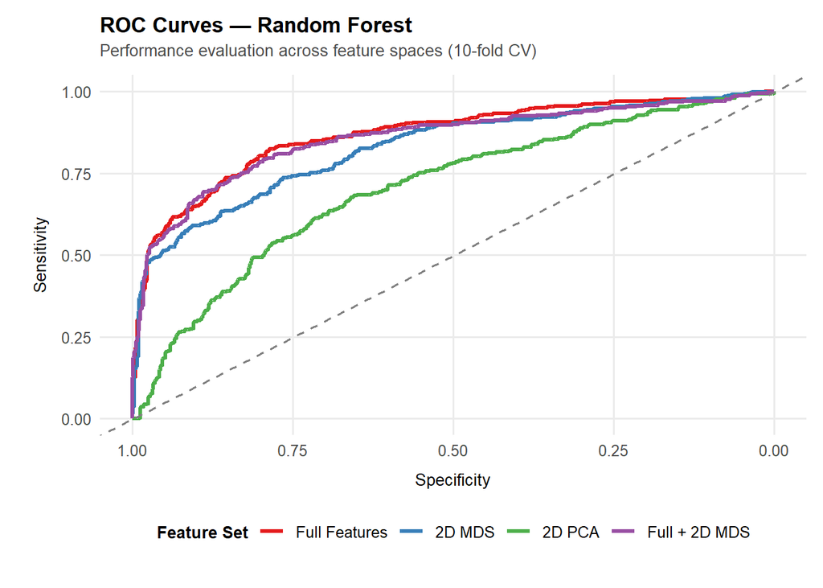

Figure 34: ROC Curves Comparison Across Feature Spaces for Random Forest.

The ROC curves show very similar performance for `Full Features` and `Full + 2D MDS`, with `2D MDS` performing only slightly worse. In contrast, `2D PCA` consistently shows the lowest performance.

#### 7.2.4.3 Random Forest Performance

All classification metrics were calculated from pooled out-of-fold predictions obtained through 10-fold CV (Table 13).

| Feature Set | AUC | Accuracy | Sensitivity | Specificity | F1 |
| --- | --- | --- | --- | --- | --- |
| Full Features | 0.8668 | 0.8021 | 0.6558 | 0.8934 | 0.7180 |
| 2D MDS | 0.8275 | 0.7693 | 0.6206 | 0.8621 | 0.6739 |
| 2D PCA | 0.7041 | 0.6873 | 0.5352 | 0.7821 | 0.5680 |
| Full + 2D MDS | 0.8558 | 0.8079 | 0.6382 | 0.9138 | 0.7185 |

Table 13: Random Forest Performance Metrics Across Feature Spaces (10-fold CV).

The `Full Features` model achieved the best overall performance, with an $\text{AUC}$ of $0.8668$ and $\text{Sensitivity}$ of $0.6558$. The hybrid model (`Full + 2D MDS`) achieved the highest $\text{Accuracy}$ ($0.8079$), $\text{Specificity}$ ($0.9138$), and $\text{F1}$ score ($0.7185$). As in the previous models, `2D PCA` performed noticeably worse, with an $\text{AUC}$ of $0.7041$.

Compared to the single decision tree, the Random Forest model achieves higher $\text{AUC}$ scores across all evaluated feature spaces. Specifically, for `Full Features`, the $\text{AUC}$ increases from $0.8336$ to $0.8668$. While other metrics remain very similar because much of the information related to survival is captured by simple binary splits, the Random Forest provides superior class separation, more reliable probability estimates, and greater overall stability.

To take a closer look at the classification errors of the `Full Features` model, its out-of-fold confusion matrix is shown in Figure 35.

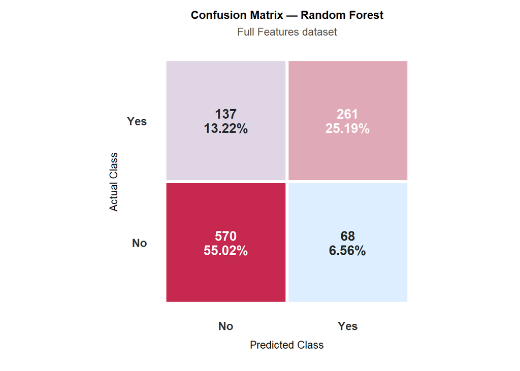

Figure 35: Confusion Matrix Heatmap for Best Model (Full Features).

The confusion matrix for the `Full Features` model shows higher specificity than sensitivity. The model correctly classifies $570$ non-survivors, which represents $55.02\%$ of all observations and corresponds to a specificity of $89.34\%$. There are $68$ false positives, accounting for $6.56\%$ of the sample.

For survivors, the model correctly identifies $261$ cases, or $25.19\%$ of all observations, resulting in a sensitivity of $65.58\%$. The remaining $137$ survivors are incorrectly classified as non-survivors, representing $13.22\%$ of the sample.

Overall, the model produces more false negatives than false positives, meaning that it is more likely to classify survivors as non-survivors than the other way around.

### 7.2.5 Support Vector Machine

*Support Vector Machine* (SVM) is a supervised learning method that identifies the observations closest to the class separation and uses them to determine the classification of the remaining observations. The radial basis function (RBF) kernel was used to allow the model to capture non-linear relationships between the features and survival. Since SVM is sensitive to the scale of the features, variables were standardized within CV folds before fitting the model.

#### 7.2.5.1 Parameter Tuning

To improve the stability and performance of the models, two parameters were optimized (Figure 36).

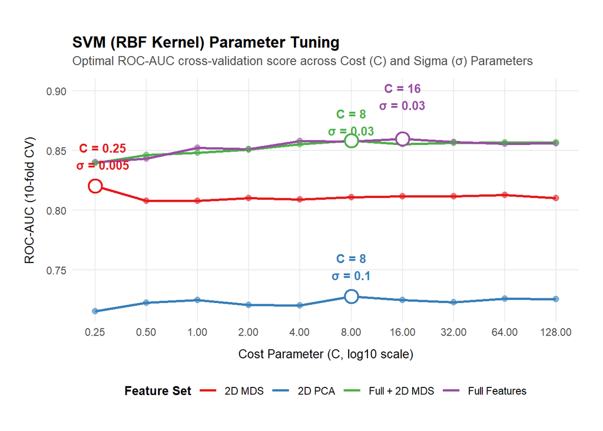

Figure 36: SVM Parameter Tuning. Cost parameter ($C$) evaluated at the optimal kernel width ($\sigma$) for each feature space.

The cost parameter ($C$) controls the balance between a wider margin and penalties for misclassified observations, while the kernel width ($\sigma$) determines how far the influence of individual support vectors extends. The best ROC-AUC results were obtained for `Full Features` ($C = 16, \sigma = 0.03$) and `Full + 2D MDS` ($C = 8, \sigma = 0.03$), suggesting that these parameter settings provided a good balance between model flexibility and generalization.

#### 7.2.5.2 Comparing Different Feature Spaces

To evaluate classification performance across different feature sets for the tuned SVM models, ROC curves were generated using out-of-fold CV predictions (Figure 37).

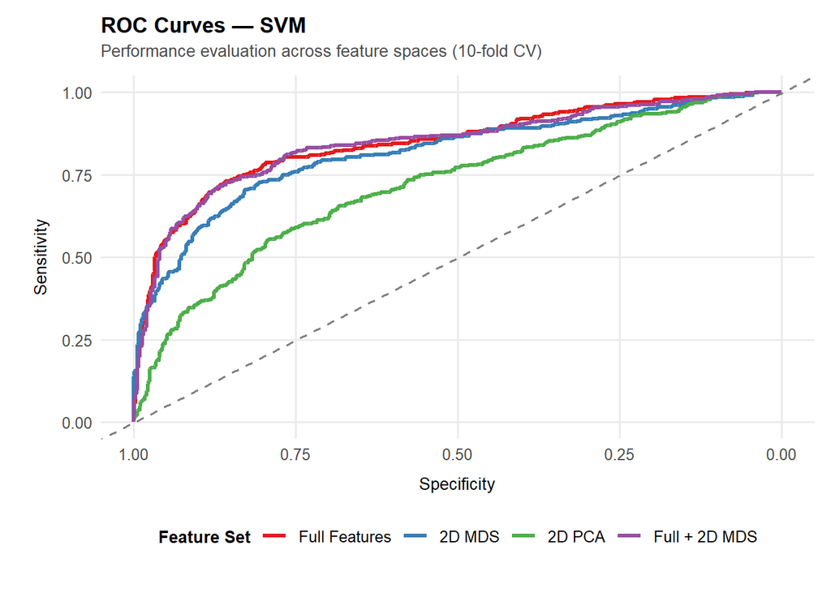

Figure 37: ROC Curves Comparison Across Feature Spaces for SVM.

The ROC curves show very similar performance for `Full Features` and `Full + 2D MDS`, with `2D MDS` performing only slightly worse. In contrast, `2D PCA` consistently shows the lowest performance.

#### 7.2.5.3 SVM Performance

All classification metrics were calculated from pooled out-of-fold predictions obtained through 10-fold CV (Table 14).

| Feature Set | AUC | Accuracy | Sensitivity | Specificity | F1 |
| --- | --- | --- | --- | --- | --- |
| Full Features | 0.8465 | 0.8021 | 0.6382 | 0.9044 | 0.7125 |
| 2D MDS | 0.8160 | 0.7770 | 0.6910 | 0.8307 | 0.7042 |
| 2D PCA | 0.7165 | 0.6882 | 0.3693 | 0.8871 | 0.4765 |
| Full + 2D MDS | 0.8449 | 0.8041 | 0.6382 | 0.9075 | 0.7145 |

Table 14: SVM Performance Metrics Across Feature Spaces (10-fold CV).

The `Full Features` space achieved the highest AUC ($0.8465$), indicating the best overall ability to distinguish between the two classes of `survival`. The hybrid space (`Full + 2D MDS`) performed best in terms of $\text{Accuracy}$ ($0.8041$), $\text{Specificity}$ ($0.9075$), and $\text{F1}$ score ($0.7145$). In contrast, `2D MDS` achieved the highest $\text{Sensitivity}$ ($0.6910$), although this came with lower specificity. As in the previous models, `2D PCA` performed worse across most metrics, with an $\text{AUC}$ of $0.7165$ and an $\text{F1}$ score of $0.4765$.

To examine the classification errors of the `Full Features` model in more detail, its out-of-fold confusion matrix is shown in Figure 38.

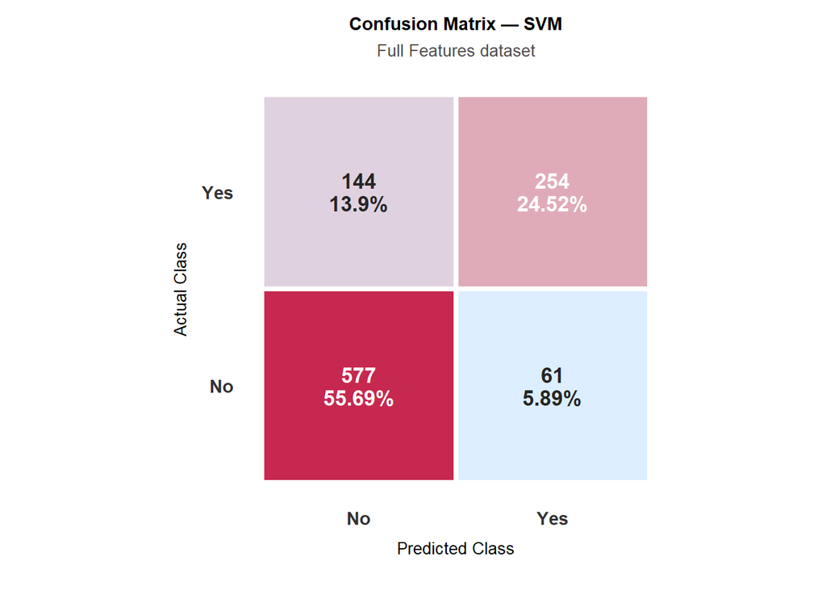

Figure 38: Confusion Matrix Heatmap for Best Model (Full Features).

The confusion matrix for the `Full Features` model shows higher specificity than sensitivity. The model correctly classifies $577$ non-survivors, which represents $55.69\%$ of all observations and corresponds to a specificity of $90.44\%$. There are $61$ false positives, accounting for $5.89\%$ of the sample.

For survivors, the model correctly identifies $254$ cases, or $24.52\%$ of all observations, resulting in a sensitivity of $63.82%$. The remaining $144$ survivors are incorrectly classified as non-survivors, representing $13.90%$ of the sample.

Overall, the model produces more false negatives than false positives, meaning that it is more likely to classify survivors as non-survivors than the other way around.

## 7.3 Models Performance Summary

A comparison of the best-performing variants for each supervised learning algorithm (by AUC value) shows fairly consistent performance across the CV results (Table 15). The corresponding ROC curves are shown in Figure 39.

[figure not shown]

Figure 39: Out-of-fold ROC curves for the best-performing supervised models. For each method, the feature set with the highest AUC is included.

One clear pattern is that most models reach a similar accuracy level, around $80\%$–$81\%$. The single *Decision Tree* achieved the heighest accuracy ($0.8118$), but its AUC was lower ($0.8336$), indicating that its ability to distinguish between the two classes was somewhat weaker. This difference is due to the fact that Accuracy is evaluated at the default classification threshold of $0.5$, while AUC reflects the model’s ability to distinguish between the two classes across different classification thresholds.

The `Full Features` *Random Forest* achieved the highest AUC ($0.8668$), suggesting the strongest overall class discrimination among the evaluated models. Using an ensemble of trees also results in smoother probability estimates than those produced bu a single *Decision Tree*.

| Model | Feature Set | AUC | Accuracy | Sensitivity | Specificity | F1 |
| --- | --- | --- | --- | --- | --- | --- |
| Random Forest | Full Features | 0.8668 | 0.8021 | 0.6558 | 0.8934 | 0.718 |
| Logistic Regression | Full + 2D MDS | 0.8483 | 0.8002 | 0.7161 | 0.8527 | 0.7336 |
| SVM (RBF) | Full Features | 0.8465 | 0.8021 | 0.6382 | 0.9044 | 0.7125 |
| k-Nearest Neighbours | Full + 2D MDS | 0.843 | 0.7857 | 0.6432 | 0.8746 | 0.6975 |
| Decision Tree | Full Features | 0.8336 | 0.8118 | 0.6809 | 0.8934 | 0.7354 |

Another common pattern among the better-performing models, including SVM and *Random Forest*, is the difference between high Specificity (around $90\%$) and more moderate Sensitivity (around $64\%$). At the default decision threshold of $0.5$, the models therefore tend to classify non-survivors more reliably than survivors.

This pattern is partly related to the strong association between passenger sex and survival, with male passengers being much more likely to belong to the non-survivor class. A similar pattern can be seen in the clustering results, e.g., PAM with $k = 2$ ($\approx 93\%$ Specificity) produced two clusters that perfectly separated the passengers by sex, with one cluster containing only female passengers and the other containing only male passengers.

## 7.4 Final Model Selection & Test

### 7.4.1 Selection

Based on the cross-validation results, the **Random Forest** model trained on the `Full Features` set was selected as the final model, as it achieved the highest ROC-AUC among all evaluated models.

To obtain an unbiased estimate of its performance and asses whether the parameter tuning introduced any overfitting during cross-validation, the final model was evaluated on an independent test set. It contained $20\%$ of the data and was not used during model development.

### 7.4.2 Test Set Performance

The evaluation on the test set shows that the model’s performance remained consistent with the CV estimates (Table 16).

| Evaluation Subset | AUC | Accuracy | Sensitivity | Specificity | F1 |
| --- | --- | --- | --- | --- | --- |
| Training Set (10-fold CV) | 0.8668 | 0.8021 | 0.6558 | 0.8934 | 0.7180 |
| Test Set | 0.8542 | 0.8062 | 0.6263 | 0.9182 | 0.7126 |

Table 16: Random Forest performance using Train Set (Full Features, CV) and Test Set.

The model maintained strong performance on unseen data, achieving an $\text{AUC}$ of $0.8542$ and an $\text{Accuracy}$ of $0.8062$. These results are close to the corresponding 10-fold CV estimates ($\text{AUC} = 0.8668$, $\text{Accuracy} = 0.8021$). The minimal performance difference ($\Delta \text{AUC} = 0.0126$) suggest that the model generalizes well to unseen observations does not suffer from overfitting.

To inspect the error distribution on the test set, the confusion matrix was created (Figure 40).

[figure not shown]

Figure 40: Confusion Matrix Heatmap on Test Set (Random Forest — Full Features).

Consistent with the cross-validation results, the model achieves higher specificity than sensitivity on the unseen test data. It is more effective at identifying non-survivors, while being more conservative when predicting survival at the default $0.5$ probability threshold.

# 8 Conclusions

The key takeaways from this analysis are:

- **Primary determinants of survival** (Section 4)

  Passenger sex emerged as the single most important factor associated with survival. Women were considerably more likely to survive than men. In fact, using sex alone as a predictor — as illustrated by the PAM clustering results (Section 7.1.1) — yields an accuracy of approximately $78\%$. The second most important factor was class of travel. However, its effect was particularly pronounced among men in first class and among women, while survival rates for men in second and third class were relatively similar.

  Other factors associated with survival included family size, fare, and age. Passengers travelling in smaller family groups generally had higher survival rates, while fare was strongly related to class of travel. Age also played a role, with younger passengers generally having higher survival rates. However, these factors had a much smaller impact than sex and class.
- **Models performance is bottlenecked** (Section 7)

  The modeling results suggest that the dataset has a natural accuracy ceiling of approximately $80$–$82\%$, likely reflecting the noise and uncertainty in the data. This is unsurprising, as survival in a maritime disaster such as the Titanic was influenced by numerous factors that cannot be fully captured by the available variables. Although ensemble models achieve accuracy comparable to that of simpler classifiers, they perform better in terms of model quality and generalization abilities, as indicated by their higher $\text{AUC}$ values.

  The best-performing model was a *Random Forest* trained on `Full Features` dataset, achieving an $\text{AUC} = 0.8668$ and an $\text{Accuracy} = 0.8021$. On the test subset, it achieved an $\text{AUC} = 0.8542$ and an $\text{Accuracy} = 0.8062$. The similar performance across the training and test subsets suggests that the model did not suffer from overfitting.
- **Potential for improvement**

  The main limitation of the analysis is the large amount of missing information. One of the potentially most informative variables is `Cabin`, which contains information about the deck on which a passenger’s cabin was located. This variable was excluded from the analysis because most of its values are missing. This is not properly reflected in the Table 1, because `Cabin` has wrongly coded missing values.